# PFG-bank: Data Driven Credit Card Design

- Team-lead gitlab id: rsm-n1gong
- Group number: 12
- Group name: Team 12
- Team member names: Nawen Gong, Zichen Zhang, Zheng Shan, Xinyue Tao

## Setup

Please complete this R-markdown document by answering the questions in `pfg-bank.pdf` on Dropbox (week10/readings/). The code block below will load the historical data from exhibits 1 and 2. Please DO NOT change the code used to load the data. Create an HTML (Notebook) file with all your results and comments and push both the Rmarkdown and HTML file to GitLab when you are done. All analysis results MUST be reproducible (i.e., the TA and I must be able to recreate the HTML from the R-markdown file without changes or errors).

## Question answers

**Q1. Why does Lifetime Customer Value vary with BK score? Why does Lifetime Customer Value vary with product? (See Exhibit 2 to help answer these questions)**

The BK score is a measure of risk —— the higher the score, the more likely that person was to default on a financial obligation. Thus, it is clear to see that person with lower BK score will have higher CLV.

Besides that, CLV also vary with product.

1. the higher the APR, the higher the CLV: APR was the rate of interest charged on outstanding balance. So, the higher APR which means the more finance charges the customer accrued, will definitely leads to higher CLV.
2. the higher the annual fee, the higher the CLV: Annual fee is a key determinant of the credit card’s profitability, so higher annual fee will contribute to higher CLV.
3. the variable-rate products enjoy higher CLV than the fixed rate products: The advantage of a variable-rate card is that bank could pass along most of the interest-rate risk to the customers. So PFG bank will undoubtedly prefer the variable-rate products, and this preference is accounted for in the CLV estimates.

**Q2. Are predictive models estimated on historical data useful in this case? If so, why? If not, why not?**

Yes. The historical model helped us to get predicted response probability which was then used to filter out products/BK pairs we don’t think should be mailed. Without the historical data, we would have to mail based on either 12~18 partial factorial product combinations or mail all 36 combinations, making the test round 1 inefficient. With the helpful historical data, we first projected to 1.52million population, then trained the logistic model and finally predicted on 18 products to filter out 2 combinations in round 1. In this way, we saved customers for the final round and reduced cost.

**Q3. Is there a “best product” that will likely be preferred by all customers?**

Yes. Based on our round 1 result, we were able to train a model that later helped us to discover the very product that is profitable among all BK scores:

apr: 14.9; Fixed_var: Var; Annual_fee: 0.

**Q4. Describe and justify your testing strategy.**

For round two, we now have the true information to reflect the product/BK response rate, so we are able to train another model using the newly projected population based on round one result. Then fit the model on the full combination to select products. Since we won’t be using experiment design anymore, we now added interactions in the logistic model for the prediction. With the prediction, we pick the product that generate the highest expected LTV for each BK score. Finally, we realized that there is one product that can provide the highest expected ltv for all scores, which is apr: 14.9/ Fixed_var: Var/ Annual_fee: 0.

We mail this offer to all the customers left, and get the round 2 profit of $755,144.

### Highest resp?

```
# A tibble: 14 x 11
   date        apr fixed_var annual_fee visamc nr_mailed non_resp  resp bk_score average_bk  respct
   <chr>     <dbl> <chr>          <dbl> <chr>      <dbl>    <dbl> <dbl>    <dbl>      <dbl>   <dbl>
 1 November   14.9 Fixed              0 Visa       50000    47549  2451      150        190 0.0490
 2 September  16.8 Fixed              0 Visa       65000    62484  2516      250        255 0.0387
 3 April      16.8 Fixed              0 MC         81000    78104  2896      200        210 0.0358
 4 September  14.9 Fixed             20 Visa      177000   172671  4329      250        255 0.0245
 5 September  19.8 Fixed              0 Visa       95000    92885  2115      250        255 0.0223
 6 November   14.9 Fixed             20 Visa       82000    80239  1761      150        190 0.0215
 7 April      19.8 Fixed              0 MC        100000    97948  2052      200        210 0.0205
 8 September  14.9 Variable          20 Visa      170000   166996  3004      250        255 0.0177
 9 November   14.9 Variable          20 Visa       50000    49292   708      150        190 0.0142
10 September  16.8 Fixed             20 Visa      255000   252017  2983      250        255 0.0117
11 April      16.8 Fixed             20 MC        167000   165467  1533      200        210 0.00918
12 November   16.8 Fixed             20 Visa       50000    49627   373      150        190 0.00746
13 September  19.8 Fixed             20 Visa       35000    34825   175      250        255 0.005
14 April      19.8 Fixed             20 MC        143000   142410   590      200        210 0.00413
```

## Scale EX1 to the full population based on resp rate

```
[1] 0.01808289
```

### Build logitistic model based on the sim.dataset

```
Logistic regression (GLM)
Data                 : EX1_gathered_dat
Response variable    : open
Level                : resp in open
Explanatory variables: apr, fixed_var, annual_fee, bk_score
Null hyp.: there is no effect of x on open
Alt. hyp.: there is an effect of x on open
**Standardized odds-ratios and coefficients shown (2 X SD)**

                       OR coefficient std.error  z.value p.value
 (Intercept)                   -2.809     0.016 -175.303  < .001 ***
 apr|16.8           0.471      -0.752     0.019  -39.875  < .001 ***
 apr|19.8           0.257      -1.358     0.024  -57.254  < .001 ***
 fixed_var|Variable 0.741      -0.300     0.021  -14.336  < .001 ***
 annual_fee|20      0.290      -1.239     0.015  -84.444  < .001 ***
 bk_score|200       1.232       0.209     0.024    8.519  < .001 ***
 bk_score|250       1.425       0.354     0.019   18.388  < .001 ***

Signif. codes:  0 '***' 0.001 '**' 0.01 '*' 0.05 '.' 0.1 ' ' 1

Pseudo R-squared: 0.033
Log-likelihood: -132938.55, AIC: 265891.101, BIC: 265976.74
Chi-squared: 9185.877 df(6), p.value < .001
Nr obs: 1,520,000
```

### Predict on Ex2

### Predict the response probability using logit model

```
# A tibble: 6 x 8
  offer apr   fixed_var annual_fee BK       LTV bk_score    pred
  <dbl> <fct> <chr>     <fct>      <fct>  <dbl> <fct>      <dbl>
1     1 14.9  Fixed     20         ltv150    83 150      0.0171
2     2 14.9  Variable  20         ltv150    93 150      0.0128
3     3 14.9  Fixed     0          ltv150    52 150      0.0568
4     4 14.9  Variable  0          ltv150    62 150      0.0427
5     5 16.8  Fixed     20         ltv150   103 150      0.00816
6     6 16.8  Variable  20         ltv150   113 150      0.00605
```

### Get “expected LTV” = response probability * estimated LTV

```
# A tibble: 6 x 9
  offer apr   fixed_var annual_fee BK       LTV bk_score    pred exp_ltv
  <dbl> <fct> <chr>     <fct>      <fct>  <dbl> <fct>      <dbl>   <dbl>
1     1 14.9  Fixed     20         ltv150    83 150      0.0171    1.42
2     2 14.9  Variable  20         ltv150    93 150      0.0128    1.19
3     3 14.9  Fixed     0          ltv150    52 150      0.0568    2.95
4     4 14.9  Variable  0          ltv150    62 150      0.0427    2.65
5     5 16.8  Fixed     20         ltv150   103 150      0.00816   0.840
6     6 16.8  Variable  20         ltv150   113 150      0.00605   0.684
```

```
# A tibble: 36 x 9
   offer apr   fixed_var annual_fee BK       LTV bk_score   pred exp_ltv
   <dbl> <fct> <chr>     <fct>      <fct>  <dbl> <fct>     <dbl>   <dbl>
 1     3 14.9  Fixed     0          ltv150    52 150      0.0568   2.95
 2     3 14.9  Fixed     0          ltv200    32 200      0.0691   2.21
 3     3 14.9  Fixed     0          ltv250     2 250      0.0791   0.158
 4     1 14.9  Fixed     20         ltv150    83 150      0.0171   1.42
 5     1 14.9  Fixed     20         ltv200    63 200      0.0210   1.33
 6     1 14.9  Fixed     20         ltv250    33 250      0.0243   0.801
 7     4 14.9  Variable  0          ltv150    62 150      0.0427   2.65
 8     4 14.9  Variable  0          ltv200    42 200      0.0521   2.19
 9     4 14.9  Variable  0          ltv250    12 250      0.0598   0.717
10     2 14.9  Variable  20         ltv150    93 150      0.0128   1.19
# … with 26 more rows
```

### Using 0.5(cost per mail) / ltv as break-even

```
# A tibble: 6 x 11
  offer apr   fixed_var annual_fee BK       LTV bk_score   pred exp_ltv      BE  mail
  <dbl> <fct> <chr>     <fct>      <fct>  <dbl> <fct>     <dbl>   <dbl>   <dbl> <dbl>
1     3 14.9  Fixed     0          ltv150    52 150      0.0568   2.95  0.00962     1
2     3 14.9  Fixed     0          ltv200    32 200      0.0691   2.21  0.0156      1
3     3 14.9  Fixed     0          ltv250     2 250      0.0791   0.158 0.25        0
4     1 14.9  Fixed     20         ltv150    83 150      0.0171   1.42  0.00602     1
5     1 14.9  Fixed     20         ltv200    63 200      0.0210   1.33  0.00794     1
6     1 14.9  Fixed     20         ltv250    33 250      0.0243   0.801 0.0152      1
```

### Customer / offer pairs don’t mail based on BE

```
# A tibble: 4 x 11
  offer apr   fixed_var annual_fee BK       LTV bk_score    pred exp_ltv      BE  mail
  <dbl> <fct> <chr>     <fct>      <fct>  <dbl> <fct>      <dbl>   <dbl>   <dbl> <dbl>
1     3 14.9  Fixed     0          ltv250     2 250      0.0791    0.158 0.25        0
2    10 19.8  Variable  20         ltv150   141 150      0.00331   0.467 0.00355     0
3    10 19.8  Variable  20         ltv200   121 200      0.00408   0.493 0.00413     0
4    10 19.8  Variable  20         ltv250    91 250      0.00471   0.429 0.00549     0
```

### Get 18 combination of offers

```
# A tibble: 6 x 5
  trial apr   Finxed_var Annual_fee BK
  <dbl> <fct> <chr>      <fct>      <fct>
1     1 14.9  Fixed      0          150
2     2 14.9  Fixed      0          200
3     3 14.9  Fixed      0          250
4    10 14.9  Variable   20         150
5    11 14.9  Variable   20         200
6    12 14.9  Variable   20         250
```

### Join the 18 offers with 36 combiantions from Ex2 to get LTV of each customer

```
# A tibble: 6 x 12
  trial apr   Fixed_var Annual_fee BK    offer BK.y     LTV   pred exp_ltv      BE  mail
  <dbl> <fct> <chr>     <fct>      <fct> <dbl> <fct>  <dbl>  <dbl>   <dbl>   <dbl> <dbl>
1     1 14.9  Fixed     0          150       3 ltv150    52 0.0568   2.95  0.00962     1
2     2 14.9  Fixed     0          200       3 ltv200    32 0.0691   2.21  0.0156      1
3     3 14.9  Fixed     0          250       3 ltv250     2 0.0791   0.158 0.25        0
4    10 14.9  Variable  20         150       2 ltv150    93 0.0128   1.19  0.00538     1
5    11 14.9  Variable  20         200       2 ltv200    73 0.0157   1.14  0.00685     1
6    12 14.9  Variable  20         250       2 ltv250    43 0.0181   0.778 0.0116      1
```

> We pick offers using Break-even Rate = 0.5/LTV, filtered out 2 offers and email the rest offer to 4000 of each BK score, here’s our ourcome

```
# A tibble: 6 x 7
    apr Fixed_var Annual_fee    BK Nr_Sent respd num_resp
  <dbl> <chr>     <chr>      <dbl>   <dbl> <chr>    <dbl>
1  14.9 Fixed     $20          150       0 Resp         0
2  14.9 Var.      $20          150      NA Resp        41
3  14.9 Fixed     $0           150      NA Resp       156
4  14.9 Var.      $0           150       0 Resp         0
5  16.8 Fixed     $20          150      NA Resp        10
6  16.8 Var.      $20          150       0 Resp         0
```

### using the round one outcome, we are able to project the dataset to the whole population and to train the new logit model with interactions and then to predict on the all combination offers.

### For each bk score, we pick only the highest expected ltv product to mail:

*apr: 14.9; Fixed_var: Var; Annual_fee: 0*

```
# A tibble: 3 x 7
    apr Fixed_var Annual_fee   LTV    BK pred_fromr1 exp_ltv
  <dbl> <chr>          <dbl> <dbl> <dbl>       <dbl>   <dbl>
1  14.9 Var                0    62   150      0.0623    3.86
2  14.9 Var                0    42   200      0.0835    3.51
3  14.9 Var                0    12   250      0.0999    1.20
```

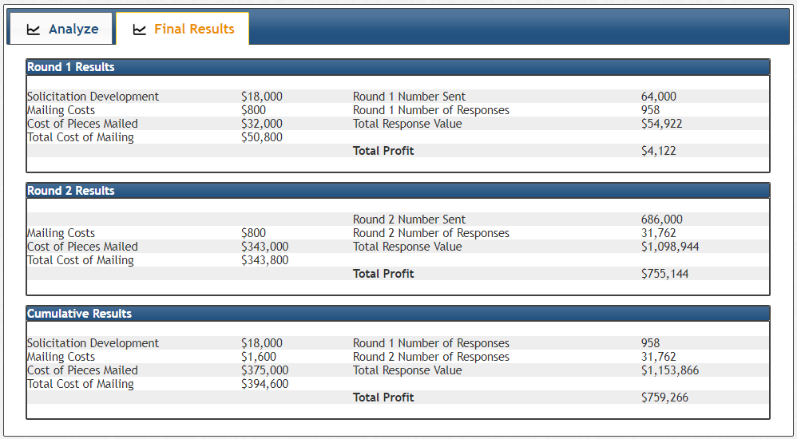

round2